# Avengers ELO Rating

[figure not shown]

https://www.flickr.com/photos/tales2astonish/6976086962

## Objective

Classify the streght of Marvel Cinematic Universe characters using ELO algorithm

## Inspirations

## Dragon Ball Power Levels

[figure not shown]

https://www.pinterest.it/pin/812899801474131186/

## The ELO Rating Calculation Alghoritm

\[ \begin{array}{lll} r_{i} & \leftarrow & r_i + \kappa (s_{i,j} - \mu_{i,j}) \\ r_j & \leftarrow & r_j + \kappa (s_{j,i} - \mu_{j,i}) \end{array} \] with:

- actual result of match: \(s_{i,j}\) (a number in [0,1] )
- predicted result: \[ \begin{array}{lll} \mu_{i,j} & = & \frac{1}{1 + 10^{-(r_i - r_j) / \zeta}} = \frac{10^{r_i / \zeta}}{10^{r_i / \zeta} + 10^{r_j / \zeta}} \\\\ \end{array} \]
- actual score of a player: \(r_i\)
- a learing rate k

## Building my Dataset

## My sample

### Movies

| My movies: |
| --- |
| Captain America |
| Iron Man |
| L’incredibile Hulk |
| Iron Man 2 |
| Thor |
| Avengers |

### Dataset Structure

| id | movie | winner | loser | comment | terrain_winner | terrain_loser |
| --- | --- | --- | --- | --- | --- | --- |
| 1 | Captain America | 1-civilian | Steve Rogers | scena bullo cinema | land | land |
| 2 | Captain America | Bucky | 1-civilian | scena bullo cinema | land | land |
| 3 | Captain America | Red Skull | 1-civilian | scena scoperta cubo | land | land |
| 4 | Captain America | 3-Hydra soldier | 3-US Army Soldier | scena creazione captain america | land | land |
| 5 | Captain America | 3-Hydra soldier | Abrahm Eskine | scena creazione captain america | land | land |

## The concept of fight

### Variants

I have different variants of fights:

- 1 vs 1

| id | winner | loser |
| --- | --- | --- |
| 13 | Captain America | Red Skull |

- 1 vs many

| id | winner | loser |
| --- | --- | --- |
| 49 | Iron Man | 11-terrorist |

### More Variants

- many vs 1 (or many vs many)

| id | winner | loser |
| --- | --- | --- |
| 30 | 50-Hydra soldier | Captain America |
| 34 | 50-US Army Soldier WW2 | 31-Hydra Soldier |

- more than one winner

| id | winner | loser |
| --- | --- | --- |
| 23 | Captain America,Bucky | 1-Hydra soldier |

### More Variants (2)

- partial damange

| id | winner | loser |
| --- | --- | --- |
| 93 | 5-US Army Soldier | 0.1-Hulk |

## Data Manipulations

## Data Tiding

### Standardize winner-loser labels + extract data

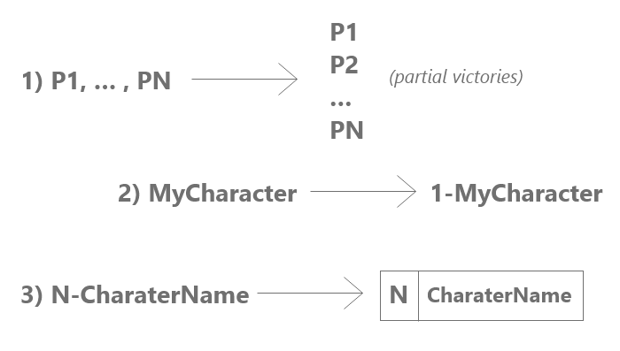

### Operations

- Separate “character 1,character 2,…” into more partial victories (w 1/n “winning rate”)
- Turn single “charater” into “1-character”
- separate pairs “n-character” in 2 columns

### Results

| id | winner_n | winner_character | loser_n | loser_character |
| --- | --- | --- | --- | --- |
| 1 | 1 | civilian | 1 | Steve Rogers |
| 2 | 1 | Bucky | 1 | civilian |
| 3 | 1 | Red Skull | 1 | civilian |
| 4 | 3 | Hydra soldier | 3 | US Army Soldier |
| 5 | 3 | Hydra soldier | 1 | Abrahm Eskine |

## Character list (+ win-lose count)

| id | character | n_fights | n_win | n_lose |
| --- | --- | --- | --- | --- |
| 11 | Iron Man | 57 | 42 | 15 |
| 17 | Hulk | 56 | 37 | 19 |
| 41 | Loki | 52 | 29 | 23 |
| 37 | Thor | 52 | 37 | 15 |
| 7 | Captain America | 40 | 31 | 9 |

## ELO Classification

## Prepare the dataframe for ELO

### Expected Format

| White | Black | Score |
| --- | --- | --- |
| 15 | 44 | 1.0 |
| 22 | 16 | 0.0 |
| 140 | 90 | 0.5 |

### My Choices

- Winner goes always in White, Loser goes always in Black => score will be always a numbers in (0.5,1]
- given n winners and m losers, I break them in this way
  - m/n lines with Score=1
  - (eventually) one line with \[Score=\frac{rest(\frac{m}{n})}{n} * 0.5 + 0.5\]
- (Instead of character names, I should use IDs)

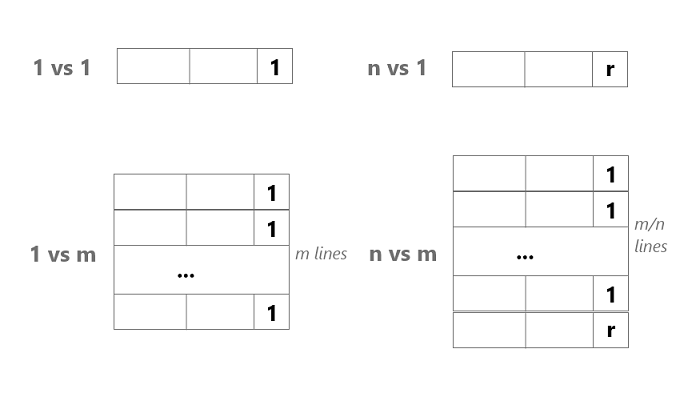

\[r=\frac{rest(\frac{m}{n})}{n} * 0.5 + 0.5\]

### Dataset in ELO Format

| id | White | winner | Black | loser | Score |
| --- | --- | --- | --- | --- | --- |
| 1 | 1 | civilian | 59 | Steve Rogers | 1.0000000 |
| 2 | 2 | Bucky | 1 | civilian | 1.0000000 |
| 3 | 3 | Red Skull | 1 | civilian | 1.0000000 |
| 4 | 4 | Hydra soldier | 8 | US Army Soldier | 1.0000000 |
| 5 | 4 | Hydra soldier | 60 | Abrahm Eskine | 0.6666667 |

## Results and comments

### And the winner is …

### … Iron Man!

[figure not shown]

https://www.pinterest.it/pin/842173199049318100/

### Top 10 Characters

[figure not shown]

### All Data

| id | character | score |
| --- | --- | --- |
| 11 | Iron Man | 300.6436 |
| 37 | Thor | 291.5212 |
| 17 | Hulk | 247.1284 |
| 24 | Abominio | 206.5020 |
| 7 | Captain America | 199.9322 |

[figure not shown]

Something has gone wrong…

## Inconsistencies

| id | character | score |
| --- | --- | --- |
| 16 | Pepper Potts | 9.627063 |
| 58 | Chitauri Giant | 9.128754 |
| 78 | Elicopter | -7.168846 |
| 13 | Fighter | -17.107892 |

### Problems

- Inappropriate algorith
- data gathering and/or manipulation methods
- “Cinematic Distorsion” (some characters are too much “in the spotlight”)
- “Implicit Strenghts” (ex. Giant Chitauri, Military veicles, ecc…)

## Let’s go deeper

## Correlation Score-Fights

Now I try to find a correlation between score and fights results

| cor_score_tot | cor_score_win | cor_score_lose |
| --- | --- | --- |
| 0.2432623 | 0.6063202 | -0.2919486 |

## Correlation Score-Screen Time

### Screen Times

| id | character | score | screen_time |
| --- | --- | --- | --- |
| 11 | Iron Man | 300.643627 | 10144 |
| 7 | Captain America | 199.932213 | 4991 |
| 17 | Hulk | 247.128401 | 4283 |
| 37 | Thor | 291.521240 | 3628 |
| 16 | Pepper Potts | 9.627063 | 2672 |

### Plot + Linear model

[figure not shown]

```
## [1] 0.6812682
```

## Shiny App

https://emanuelena49.shinyapps.io/avengers-elo-rating/

## Links and credits

## Project links

- github: https://github.com/emanuelena49/avengers-elo-ranting-R
- shiny: https://emanuelena49.shinyapps.io/avengers-elo-rating/

## Data Sources

- The first 6 MCU movies
- Some youtube videos that count all the deaths in those movies (very helpful for 1 vs many fights):
- https://www.youtube.com/watch?v=fEP9Z3dq0TM EVERY DEATH IN #6 Iron Man (2008)
- https://www.youtube.com/watch?v=KOGSX_9tUtg The Incredible Hulk (2008) Carnage Count
- https://www.youtube.com/watch?v=TO7XClpPZJ0 EVERY DEATH IN #8 Iron Man 2 (2010)

## Data Sources (2)

- https://www.youtube.com/watch?v=aHMXdnbhIZI EVERY DEATH IN #9 Thor (2011)
- https://www.youtube.com/watch?v=_LblVsWaEBY EVERY DEATH IN #11 Captain America: The First Avenger (2011)
- https://www.youtube.com/watch?v=rPeuwkHxeQI EVERY DEATH IN #12 The Avengers (2012)
- source screen times: https://www.youtube.com/watch?v=XE0HwXz43WQ)